# Reproducible Research: Peer Assessment 1

Pengfei LI

6/23/2020

## Instruction for Course Project 1 Assignment

The assignment shall separate into five parts to make the whole process of data analysis clear to read. 1. The loading and pre-processing section; 2. The analysis for the mean total number of steps taken per day; 3. The analysis for the average daily activity pattern; 4. The analysis for Imputing missing values; 5. The comparasion about activity patterns between weekdays and weekends;

The code for data processing and plotting is also included in the following sections.

## Loading and preprocessing the data

Requirement: Show any code that is needed to 1. Load the data (i.e. read.csv()) 2. Process/transform the data (if necessary) into a format suitable for your analysis

The solution is as follow;

```r
#Check the file
file<-"activity.zip"
if(!file.exists("activity")){
        unzip(file)
}

#load the dataset
activities<-read.csv("activity.csv")
View(activities)

#preprocessing the data
activities$date<-as.POSIXct(activities$date,"%Y-%m-%d",tz="GMT")
week<-weekdays(activities$date)
View(activities)
View(week)
processed_data<-cbind(activities,week)
head(processed_data)
```

```
##   steps       date interval   week
## 1    NA 2012-10-01        0 Monday
## 2    NA 2012-10-01        5 Monday
## 3    NA 2012-10-01       10 Monday
## 4    NA 2012-10-01       15 Monday
## 5    NA 2012-10-01       20 Monday
## 6    NA 2012-10-01       25 Monday
```

```r
tail(processed_data)
```

```
##       steps       date interval   week
## 17563    NA 2012-11-30     2330 Friday
## 17564    NA 2012-11-30     2335 Friday
## 17565    NA 2012-11-30     2340 Friday
## 17566    NA 2012-11-30     2345 Friday
## 17567    NA 2012-11-30     2350 Friday
## 17568    NA 2012-11-30     2355 Friday
```

```r
str(processed_data)
```

```
## 'data.frame':    17568 obs. of  4 variables:
##  $ steps   : int  NA NA NA NA NA NA NA NA NA NA ...
##  $ date    : POSIXct, format: "2012-10-01" "2012-10-01" ...
##  $ interval: int  0 5 10 15 20 25 30 35 40 45 ...
##  $ week    : chr  "Monday" "Monday" "Monday" "Monday" ...
```

```r
dim(processed_data)
```

```
## [1] 17568     4
```

```r
summary(processed_data)
```

```
##      steps             date               interval          week
##  Min.   :  0.00   Min.   :2012-10-01   Min.   :   0.0   Length:17568
##  1st Qu.:  0.00   1st Qu.:2012-10-16   1st Qu.: 588.8   Class :character
##  Median :  0.00   Median :2012-10-31   Median :1177.5   Mode  :character
##  Mean   : 37.38   Mean   :2012-10-31   Mean   :1177.5
##  3rd Qu.: 12.00   3rd Qu.:2012-11-15   3rd Qu.:1766.2
##  Max.   :806.00   Max.   :2012-11-30   Max.   :2355.0
##  NA's   :2304
```

This process offers a method to unzip and load the data into R. Meanwhile, it finished the data pre-processing procedure, making the incoming solution easier.

## What is mean total number of steps taken per day?

This section is going to solve the first data analysis issue. The requirement is:

What is mean total number of steps taken per day? For this part of the assignment, you can ignore the missing values in the dataset. 1. Make a histogram of the total number of steps taken each day 2. Calculate and report the mean and median total number of steps taken per day

The method for these goes as follows;

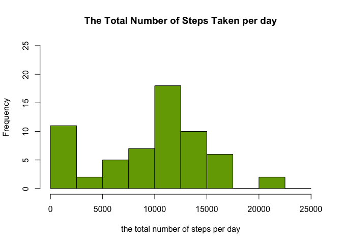

```r
##1. Make a histogram of the total number of steps taken each day
###1.Calculate the total number of steps taken per day
total_number_steps<-with(processed_data,aggregate(steps,by=list(date),
                                           FUN = sum, na.rm=TRUE))
###2.Change the Variable names
names(total_number_steps)<-c("Date","Steps")
###3.Make a histogram for "total_number_steps"
hist(total_number_steps$Steps,
     main = "The Total Number of Steps Taken per day",
     xlab = "the total number of steps per day",
     ylab = "Frequency",
     col = rgb(0.45,0.65,0),ylim = c(0,25),breaks = seq(0,25000, by=2500))
```

```r
dev.copy(png,file="1.png",height=593,width=466)
```

```r
dev.off()
```

```r
##2. Calculate and report the mean and median total number of steps taken per day
Mean_total<-mean(total_number_steps$Steps)
Median_total<-median(total_number_steps$Steps)
Mean_total
```

```
## [1] 9354.23
```

```r
Median_total
```

```
## [1] 10395
```